# Reproducible Research Project 1

Giovanni Madejski

June 28, 2017

# Introduction

This is the first project for the Reproducible Research course In the Coursera Data Science Specialization. In this project we will be answering a series of questions about a dataset containing data from a fitbit.

# Loading and Preprocessing Data

Download, unzip, and load dataset into a dataframe

```r
 if(!file.exists("repdata%2Fdata%2Factivity.zip")) {
        temp <- tempfile()
        download.file("https://d396qusza40orc.cloudfront.net/repdata%2Fdata%2Factivity.zip",temp)
        unzip(temp)
        unlink(temp)
}

data <- read.csv("activity.csv")
```

# What is the mean total number of steps taken per day?

Calculate steps per day, create histogram, find mean and median.

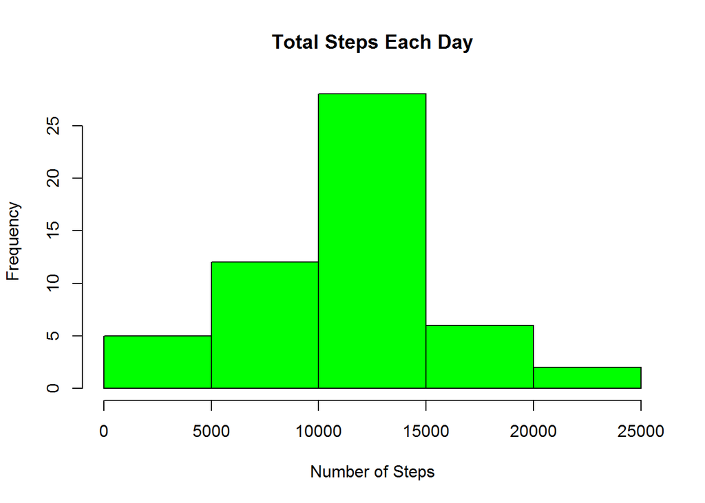

```r
dailysteps <- aggregate(steps ~ date, data, sum)
hist(dailysteps$steps, main = paste("Total Steps Each Day"), col = "Green", xlab="Number of Steps")
```

```r
stepmean <- mean(dailysteps$steps)
stepmedian <- median(dailysteps$steps)
```

The mean is 10766.19.

The median is 10765.

# What is the average daily activity pattern?

Calculate average steps per interval, Plot the average number of steps per day, Find interval with most steps.

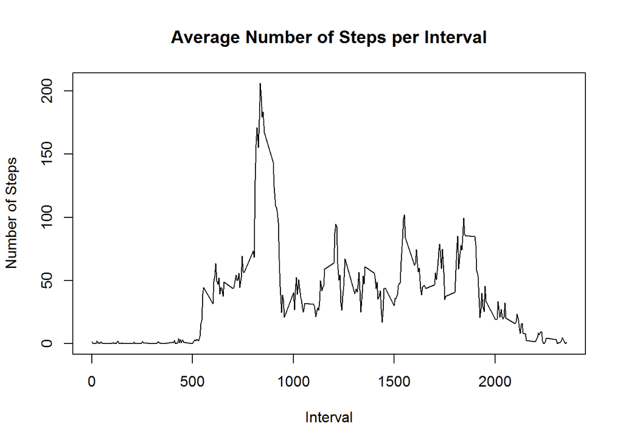

```r
intervalsteps <- aggregate(steps ~ interval, data, mean)
plot(intervalsteps$interval, intervalsteps$steps, type = "l", xlab = "Interval", ylab = "Number of Steps", main = "Average Number of Steps per Interval")
```

```r
maximum <- intervalsteps[which.max(intervalsteps$steps), 1]
```

The 5 minute interval containg the maximum average number of steps across days is 835.

# Input missing values

Report the number of missing values

```r
missingvalues <- length(which(is.na(data$steps)))
```

The number of missing values is 2304

Create a Dataset that fills in missing values with a mean value

```r
filleddata <- data
filleddata$steps <- impute(data$steps, fun=mean)
```

# Create a Histogram of the total number of steps taken each day and Calculate the mean and median steps taken per day

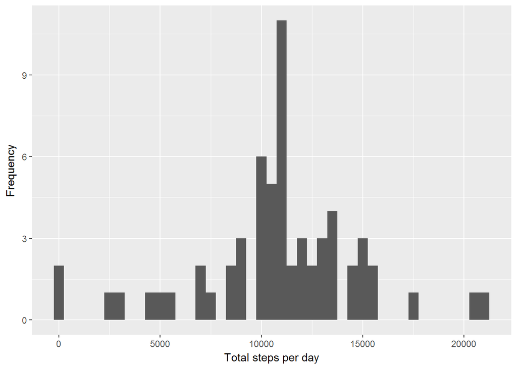

```r
stepsByDay <- tapply(filleddata$steps, filleddata$date, sum)
qplot(stepsByDay, xlab='Total steps per day', ylab='Frequency', binwidth = 500)
```

```r
stepsByDaymean <- mean(stepsByDay)
stepsByDaymedian <- median(stepsByDay)
```

The Mean is 10766.19 the Median is 10766.19.

Imputting mean data for the missing values has brought the median closer to the mean value. This makes sense as now there are a greater number of “mean” entries in the dataset.

# Are there differences in activty patterns between weekdays and weekends?

Seperate data into weekends and weekdays, then create a panel plot to compare.

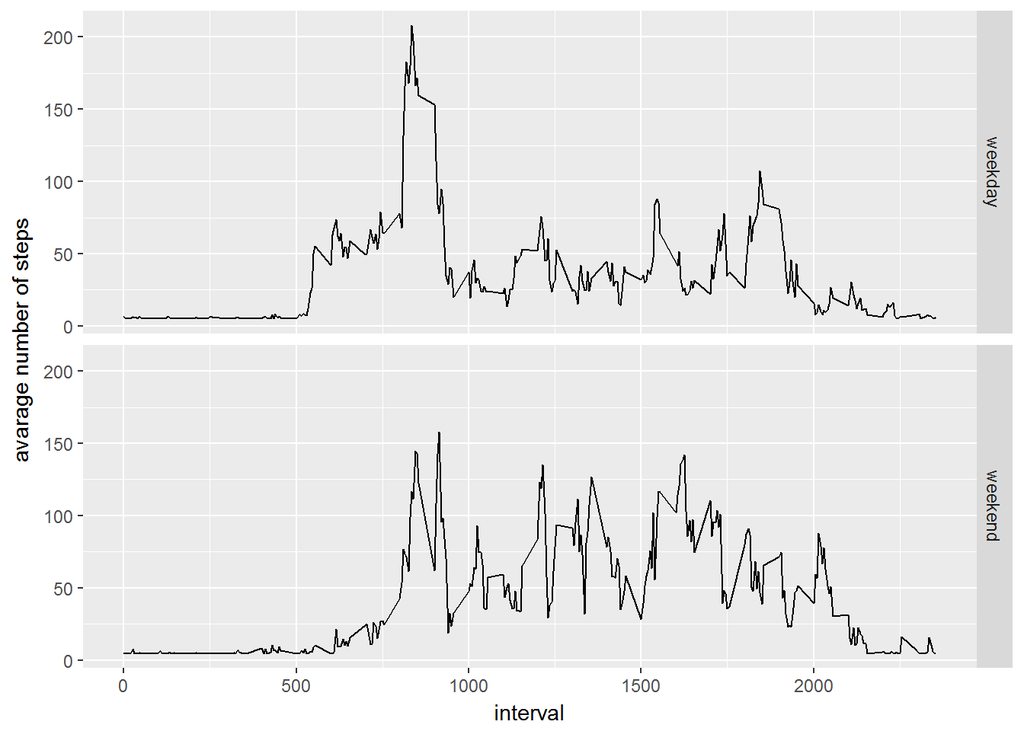

```r
filleddata$dateType <-  ifelse(as.POSIXlt(filleddata$date)$wday %in% c(0,6), 'weekend', 'weekday')
averagedfilleddata <- aggregate(steps ~ interval + dateType, data=filleddata, mean)
ggplot(averagedfilleddata, aes(interval, steps)) +
    geom_line() +
    facet_grid(dateType ~ .) +
    xlab("interval") +
    ylab("avarage number of steps")
```

This completes the project, Thank you for reading.